# Project: Investigate a Dataset (TMDb movie data)

- Introduction
- Data Wrangling
- Exploratory Data Analysis
- Conclusions

## Introduction

I have selected the movie data set from TMDB for my exploration. This dataset contains information of 10,866 movies released between 1960 to 2015 on 21 parameters.The dataset gives me an opportunity to analyse the movie watching patterns, the cast, the revenure generated from different genres of movie.

There are a number of questions that come to mind after a quick glance through the dataset. Some of them are as follows:

```
- What are the genre of movies that have been most hit?
- Is there any relation between budget and revenue generated?
- Which is the most profitable and the least profitable movie of all time?
- Which actor/actress has done most number ofsuccessful movies?
- Who is the most successful director?
- Which is the most succesful production company?
- Which has been the most succesful year so far?
- How are runtimes of movies changing over the years? Is there any corelation between runtime and popularity?
- What are the popularity trends over the years?
- What are the revenue trends over the years?
- What makes the movie successful?
```

Lets analyse the dataset to get the answer to these and more questions.

```python
# Use this cell to set up import statements for all of the packages that you
#   plan to use.

# Remember to include a 'magic word' so that your visualizations are plotted
#   inline with the notebook. See this page for more:
#   http://ipython.readthedocs.io/en/stable/interactive/magics.html

import pandas as pd
import numpy as np
import matplotlib.pyplot as plt
import seaborn as sns
from datetime import datetime
%matplotlib inline
```

## Data Wrangling

### General Properties

```python
# Load your data and print out a few lines. Perform operations to inspect data
#   types and look for instances of missing or possibly errant data.

df=pd.read_csv("tmdb-movies.csv")
df.head()
```

|  | id | imdb_id | popularity | budget | revenue | original_title | cast | homepage | director | tagline | ... | overview | runtime | genres | production_companies | release_date | vote_count | vote_average | release_year | budget_adj | revenue_adj |
| --- | --- | --- | --- | --- | --- | --- | --- | --- | --- | --- | --- | --- | --- | --- | --- | --- | --- | --- | --- | --- | --- |
| 0 | 135397 | tt0369610 | 32.985763 | 150000000 | 1513528810 | Jurassic World | Chris Pratt\|Bryce Dallas Howard\|Irrfan Khan\|Vi... | http://www.jurassicworld.com/ | Colin Trevorrow | The park is open. | ... | Twenty-two years after the events of Jurassic ... | 124 | Action\|Adventure\|Science Fiction\|Thriller | Universal Studios\|Amblin Entertainment\|Legenda... | 6/9/15 | 5562 | 6.5 | 2015 | 1.379999e+08 | 1.392446e+09 |
| 1 | 76341 | tt1392190 | 28.419936 | 150000000 | 378436354 | Mad Max: Fury Road | Tom Hardy\|Charlize Theron\|Hugh Keays-Byrne\|Nic... | http://www.madmaxmovie.com/ | George Miller | What a Lovely Day. | ... | An apocalyptic story set in the furthest reach... | 120 | Action\|Adventure\|Science Fiction\|Thriller | Village Roadshow Pictures\|Kennedy Miller Produ... | 5/13/15 | 6185 | 7.1 | 2015 | 1.379999e+08 | 3.481613e+08 |
| 2 | 262500 | tt2908446 | 13.112507 | 110000000 | 295238201 | Insurgent | Shailene Woodley\|Theo James\|Kate Winslet\|Ansel... | http://www.thedivergentseries.movie/#insurgent | Robert Schwentke | One Choice Can Destroy You | ... | Beatrice Prior must confront her inner demons ... | 119 | Adventure\|Science Fiction\|Thriller | Summit Entertainment\|Mandeville Films\|Red Wago... | 3/18/15 | 2480 | 6.3 | 2015 | 1.012000e+08 | 2.716190e+08 |
| 3 | 140607 | tt2488496 | 11.173104 | 200000000 | 2068178225 | Star Wars: The Force Awakens | Harrison Ford\|Mark Hamill\|Carrie Fisher\|Adam D... | http://www.starwars.com/films/star-wars-episod... | J.J. Abrams | Every generation has a story. | ... | Thirty years after defeating the Galactic Empi... | 136 | Action\|Adventure\|Science Fiction\|Fantasy | Lucasfilm\|Truenorth Productions\|Bad Robot | 12/15/15 | 5292 | 7.5 | 2015 | 1.839999e+08 | 1.902723e+09 |
| 4 | 168259 | tt2820852 | 9.335014 | 190000000 | 1506249360 | Furious 7 | Vin Diesel\|Paul Walker\|Jason Statham\|Michelle ... | http://www.furious7.com/ | James Wan | Vengeance Hits Home | ... | Deckard Shaw seeks revenge against Dominic Tor... | 137 | Action\|Crime\|Thriller | Universal Pictures\|Original Film\|Media Rights ... | 4/1/15 | 2947 | 7.3 | 2015 | 1.747999e+08 | 1.385749e+09 |

5 rows × 21 columns

So, the dataset has 21 columns. For each movie, its popularity, budget and revenue generated,cast,director,genre etc. are mentioned.We see that one movie can have multiple genres.

```python
df.info()
```

```
<class 'pandas.core.frame.DataFrame'>
RangeIndex: 10866 entries, 0 to 10865
Data columns (total 21 columns):
id                      10866 non-null int64
imdb_id                 10856 non-null object
popularity              10866 non-null float64
budget                  10866 non-null int64
revenue                 10866 non-null int64
original_title          10866 non-null object
cast                    10790 non-null object
homepage                2936 non-null object
director                10822 non-null object
tagline                 8042 non-null object
keywords                9373 non-null object
overview                10862 non-null object
runtime                 10866 non-null int64
genres                  10843 non-null object
production_companies    9836 non-null object
release_date            10866 non-null object
vote_count              10866 non-null int64
vote_average            10866 non-null float64
release_year            10866 non-null int64
budget_adj              10866 non-null float64
revenue_adj             10866 non-null float64
dtypes: float64(4), int64(6), object(11)
memory usage: 1.7+ MB
```

There are some columns which have rows with null values. production_companies,genres,overview,keywords,tagline,director,homepage,imdb_id and cast are those columns. We will need to investigate these later.

```python
df.shape
```

```
(10866, 21)
```

This datatset is about 10866 movies describing each one of them in 21 columns each.

```python
df.corr()
```

|  | id | popularity | budget | revenue | runtime | vote_count | vote_average | release_year | budget_adj | revenue_adj |
| --- | --- | --- | --- | --- | --- | --- | --- | --- | --- | --- |
| id | 1.000000 | -0.014350 | -0.141351 | -0.099227 | -0.088360 | -0.035551 | -0.058363 | 0.511364 | -0.189015 | -0.138477 |
| popularity | -0.014350 | 1.000000 | 0.545472 | 0.663358 | 0.139033 | 0.800828 | 0.209511 | 0.089801 | 0.513550 | 0.609083 |
| budget | -0.141351 | 0.545472 | 1.000000 | 0.734901 | 0.191283 | 0.632702 | 0.081014 | 0.115931 | 0.968963 | 0.622505 |
| revenue | -0.099227 | 0.663358 | 0.734901 | 1.000000 | 0.162838 | 0.791175 | 0.172564 | 0.057048 | 0.706427 | 0.919110 |
| runtime | -0.088360 | 0.139033 | 0.191283 | 0.162838 | 1.000000 | 0.163278 | 0.156835 | -0.117204 | 0.221114 | 0.175676 |
| vote_count | -0.035551 | 0.800828 | 0.632702 | 0.791175 | 0.163278 | 1.000000 | 0.253823 | 0.107948 | 0.587051 | 0.707942 |
| vote_average | -0.058363 | 0.209511 | 0.081014 | 0.172564 | 0.156835 | 0.253823 | 1.000000 | -0.117632 | 0.093039 | 0.193085 |
| release_year | 0.511364 | 0.089801 | 0.115931 | 0.057048 | -0.117204 | 0.107948 | -0.117632 | 1.000000 | 0.016793 | -0.066256 |
| budget_adj | -0.189015 | 0.513550 | 0.968963 | 0.706427 | 0.221114 | 0.587051 | 0.093039 | 0.016793 | 1.000000 | 0.646607 |
| revenue_adj | -0.138477 | 0.609083 | 0.622505 | 0.919110 | 0.175676 | 0.707942 | 0.193085 | -0.066256 | 0.646607 | 1.000000 |

If we see the reveneue column, we find that there is a strong postive correlation betwee and revenue and budget as well as revenue and popularity. The latter is understandable. Regarding runtimes, it has a negative correlation with release year. We will explore such correlations in the later sections.

#### Removing any duplicate rows

```python
# After discussing the structure of the data and any problems that need to be
#   cleaned, perform those cleaning steps in the second part of this section.

# Checking for duplicate rows
df[df.duplicated(keep=False)]
```

|  | id | imdb_id | popularity | budget | revenue | original_title | cast | homepage | director | tagline | ... | overview | runtime | genres | production_companies | release_date | vote_count | vote_average | release_year | budget_adj | revenue_adj |
| --- | --- | --- | --- | --- | --- | --- | --- | --- | --- | --- | --- | --- | --- | --- | --- | --- | --- | --- | --- | --- | --- |
| 2089 | 42194 | tt0411951 | 0.59643 | 30000000 | 967000 | TEKKEN | Jon Foo\|Kelly Overton\|Cary-Hiroyuki Tagawa\|Ian... | NaN | Dwight H. Little | Survival is no game | ... | In the year of 2039, after World Wars destroy ... | 92 | Crime\|Drama\|Action\|Thriller\|Science Fiction | Namco\|Light Song Films | 3/20/10 | 110 | 5.0 | 2010 | 30000000.0 | 967000.0 |
| 2090 | 42194 | tt0411951 | 0.59643 | 30000000 | 967000 | TEKKEN | Jon Foo\|Kelly Overton\|Cary-Hiroyuki Tagawa\|Ian... | NaN | Dwight H. Little | Survival is no game | ... | In the year of 2039, after World Wars destroy ... | 92 | Crime\|Drama\|Action\|Thriller\|Science Fiction | Namco\|Light Song Films | 3/20/10 | 110 | 5.0 | 2010 | 30000000.0 | 967000.0 |

2 rows × 21 columns

```python
# Removing the duplicate row
df.drop_duplicates(inplace=True)
```

```python
#Checking
df.shape
```

```
(10865, 21)
```

#### Removing unnecessary columns

```python
df.head(2)
```

|  | id | imdb_id | popularity | budget | revenue | original_title | cast | homepage | director | tagline | ... | overview | runtime | genres | production_companies | release_date | vote_count | vote_average | release_year | budget_adj | revenue_adj |
| --- | --- | --- | --- | --- | --- | --- | --- | --- | --- | --- | --- | --- | --- | --- | --- | --- | --- | --- | --- | --- | --- |
| 0 | 135397 | tt0369610 | 32.985763 | 150000000 | 1513528810 | Jurassic World | Chris Pratt\|Bryce Dallas Howard\|Irrfan Khan\|Vi... | http://www.jurassicworld.com/ | Colin Trevorrow | The park is open. | ... | Twenty-two years after the events of Jurassic ... | 124 | Action\|Adventure\|Science Fiction\|Thriller | Universal Studios\|Amblin Entertainment\|Legenda... | 6/9/15 | 5562 | 6.5 | 2015 | 1.379999e+08 | 1.392446e+09 |
| 1 | 76341 | tt1392190 | 28.419936 | 150000000 | 378436354 | Mad Max: Fury Road | Tom Hardy\|Charlize Theron\|Hugh Keays-Byrne\|Nic... | http://www.madmaxmovie.com/ | George Miller | What a Lovely Day. | ... | An apocalyptic story set in the furthest reach... | 120 | Action\|Adventure\|Science Fiction\|Thriller | Village Roadshow Pictures\|Kennedy Miller Produ... | 5/13/15 | 6185 | 7.1 | 2015 | 1.379999e+08 | 3.481613e+08 |

2 rows × 21 columns

Looking at these columns, I feel there is no use of maintaining two id columns. Let's just keep one of them. So I will get rid of imdb_id column.

I feel having tagline and overview column seems a little redundant. Anyways both of these columns do not provide any significant data that can be analysed.So, I decide to remove both of these columns.

Since we already have the budget and revenue stated, we can remove budget_adj and revenue_adj column.

There is a popularity score column. So, we dont neccesarily need the vote_vount and vote_average column. I dont think I will be using these 2 columns for any analysis.

So, overall lets remove 7 columns namely 'imdb_id,tagline,overview,budget_adj,revenue_adj,vote_count,vote_average'

```python
col=['imdb_id','tagline','overview','budget_adj','revenue_adj','vote_count','vote_average']
df.drop(labels=col,axis=1,inplace=True)
```

```python
#Checking
df.shape
```

```
(10865, 14)
```

#### Checking for columns with null values

On checking for null values in various colums, I came across certain rows, where budget and revenue were zero. Also, there were certain columns where the budeget was zero, but revenue was generated. However, as we have seen before, there are no null values in the release datecolumn. That means all these movies do have a release date.Lets look into this kind of data further.

```python
df.query('budget == 0').count()['id']
```

```
5696
```

```python
df.query('revenue==0').count()['id']
```

```
6016
```

```python
df['budget'].replace(0,None,inplace=True)
df['revenue'].replace(0,None,inplace=True)
```

```python
#Checking
print(df['budget'].isnull().sum())
print(df['revenue'].isnull().sum())
```

```
0
0
```

```python
df.isnull().sum()
```

```
id                         0
popularity                 0
budget                     0
revenue                    0
original_title             0
cast                      76
homepage                7929
director                  44
keywords                1493
runtime                    0
genres                    23
production_companies    1030
release_date               0
release_year               0
dtype: int64
```

There are some small number of null values present in cast,director and genres. Lets check these out. Again, since homepage and keywords have larger number of null values. I am going to keep them as it is.

```python
df[df.genres.isnull()]
```

|  | id | popularity | budget | revenue | original_title | cast | homepage | director | keywords | runtime | genres | production_companies | release_date | release_year |
| --- | --- | --- | --- | --- | --- | --- | --- | --- | --- | --- | --- | --- | --- | --- |
| 424 | 363869 | 0.244648 | 7500000 | 2642899 | Belli di papÃ | Diego Abatantuono\|Matilde Gioli\|Andrea Pisani\|... | NaN | Guido Chiesa | NaN | 100 | NaN | NaN | 10/29/15 | 2015 |
| 620 | 361043 | 0.129696 | 2000000 | 13684 | All Hallows' Eve 2 | NaN | NaN | Antonio Padovan\|Bryan Norton\|Marc Roussel\|Ryan... | NaN | 90 | NaN | Ruthless Pictures\|Hollywood Shorts | 10/6/15 | 2015 |
| 997 | 287663 | 0.330431 | 325927 | 2365467 | Star Wars Rebels: Spark of Rebellion | Freddie Prinze Jr.\|Vanessa Marshall\|Steve Blum... | NaN | Steward Lee\|Steven G. Lee | NaN | 44 | NaN | NaN | 10/3/14 | 2014 |
| 1712 | 21634 | 0.302095 | 14000000 | 27206120 | Prayers for Bobby | Ryan Kelley\|Sigourney Weaver\|Henry Czerny\|Dan ... | http://www.prayersforbobby.com/ | Russell Mulcahy | NaN | 88 | NaN | Daniel Sladek Entertainment | 2/27/09 | 2009 |
| 1897 | 40534 | 0.020701 | 6000000 | 90508336 | Jonas Brothers: The Concert Experience | Nick Jonas\|Joe Jonas\|Kevin Jonas\|John Lloyd Ta... | NaN | Bruce Hendricks | duringcreditsstinger | 76 | NaN | NaN | 2/27/09 | 2009 |
| 2370 | 127717 | 0.081892 | 3000000 | 427628 | Freshman Father | Britt Irvin\|Merrilyn Gann\|Barbara Tyson\|Anthon... | NaN | Michael Scott | NaN | 0 | NaN | NaN | 6/5/10 | 2010 |
| 2376 | 315620 | 0.068411 | 3000000 | 5980 | Doctor Who: A Christmas Carol | Matt Smith\|Karen Gillan\|Arthur Darvill\|Michael... | NaN | NaN | NaN | 62 | NaN | NaN | 12/25/10 | 2010 |
| 2853 | 57892 | 0.130018 | 10000000 | 7316658 | Vizontele | YÄ±lmaz ErdoÄŸan\|Demet Akbag\|Altan Erkekli\|Cem... | NaN | YÄ±lmaz ErdoÄŸan | NaN | 110 | NaN | NaN | 2/2/01 | 2001 |
| 3279 | 54330 | 0.145331 | 4180000 | 900689 | ì•„ê¸°ì™€ ë‚˜ | Jang Keun-suk\|Song Ha-yoon\|Kim Jeong-Nan | NaN | Kim Jin-Yeong | NaN | 96 | NaN | NaN | 8/13/08 | 2008 |
| 4547 | 123024 | 0.520520 | 2400000 | 30668 | London 2012 Olympic Opening Ceremony: Isles of... | Queen Elizabeth II\|Mike Oldfield\|Kenneth Brana... | http://www.london2012.com/ | Danny Boyle | NaN | 220 | NaN | BBC | 7/27/12 | 2012 |
| 4732 | 139463 | 0.235911 | 1250000 | 2750275 | The Scapegoat | Andrew Scott\|Jodhi May\|Eileen Atkins\|Matthew R... | http://www.island-pictures.co.uk/extras/the-sc... | Charles Sturridge | coronation\|rolls royce | 100 | NaN | Island Pictures | 9/9/12 | 2012 |
| 4797 | 369145 | 0.167501 | 2840000 | 11620000 | Doctor Who: The Snowmen | Matt Smith\|Jenna Coleman\|Richard E. Grant\|Ian ... | NaN | NaN | NaN | 60 | NaN | BBC Television UK | 12/25/12 | 2012 |
| 4890 | 126909 | 0.083202 | 2500000 | 33400000 | Cousin Ben Troop Screening | Jason Schwartzman | http://www.funnyordie.com/videos/fc132ce8b2/co... | Wes Anderson | NaN | 2 | NaN | NaN | 1/1/12 | 2012 |
| 5830 | 282848 | 0.248944 | 6000000 | 653651 | Doctor Who: The Time of the Doctor | Matt Smith\|Jenna Coleman | NaN | James Payne | NaN | 60 | NaN | NaN | 12/25/13 | 2013 |
| 5934 | 200204 | 0.067433 | 3000000 | 1675381 | Prada: Candy | Peter Gadiot\|Rodolphe Pauly\|LÃ©a Seydoux | NaN | Wes Anderson\|Roman Coppola | NaN | 3 | NaN | NaN | 3/25/13 | 2013 |
| 6043 | 190940 | 0.039080 | 58000000 | 44000000 | Bombay Talkies | Aamir Khan\|Rani Mukerji\|Randeep Hooda\|Saqib Sa... | http://en.wikipedia.org/wiki/Bombay_Talkies_%2... | Anurag Kashyap\|Dibakar Banerjee\|Zoya Akhtar\|Ka... | woman director | 127 | NaN | Viacom 18 Motion Pictures | 5/3/13 | 2013 |
| 6530 | 168891 | 0.092724 | 15000000 | 10422387 | Saw Rebirth | Whit Anderson\|Stan Kirsch\|Jeff Shuter\|George W... | NaN | Jeff Shuter\|Daniel Viney | NaN | 6 | NaN | NaN | 10/24/05 | 2005 |
| 8234 | 56804 | 0.028874 | 8000000 | 13071518 | Viaggi di nozze | Carlo Verdone\|Claudia Gerini\|Veronica Pivetti\|... | NaN | Carlo Verdone | NaN | 103 | NaN | NaN | 12/15/95 | 1995 |
| 8614 | 65595 | 0.273934 | 3000000 | 222559 | T2 3-D: Battle Across Time | Arnold Schwarzenegger\|Linda Hamilton\|Edward Fu... | NaN | James Cameron | NaN | 12 | NaN | NaN | 1/1/96 | 1996 |
| 8878 | 92208 | 0.038045 | 1500000 | 3728888 | Mom's Got a Date With a Vampire | Matt O'Leary\|Laura Vandervoort\|Myles Jeffrey\|C... | NaN | Steve Boyum | NaN | 85 | NaN | Walt Disney Pictures | 10/13/00 | 2000 |
| 9307 | 141859 | 0.094652 | 7000000 | 1738897 | Goldeneye | Charles Dance\|Phyllis Logan\|Patrick Ryecart\|La... | NaN | Don Boyd | nazis\|secret agent\|author\|james bond\|ian fleming | 105 | NaN | Anglia Television | 8/26/89 | 1989 |
| 9799 | 48847 | 0.175008 | 7000000 | 43008075 | The Amputee | Catherine E. Coulson\|David Lynch | NaN | David Lynch | NaN | 5 | NaN | NaN | 1/1/74 | 1974 |
| 10659 | 4255 | 0.344172 | 5000 | 5050000 | The Party at Kitty and Stud's | Sylvester Stallone\|Henrietta Holm\|Nicholas War... | NaN | Morton Lewis | male nudity\|female nudity\|group sex\|erection\|p... | 71 | NaN | Stallion Releasing Inc. | 2/10/70 | 1970 |

Since, I am going to analyse the data genre wise, I will remove the rows where genre is null. anyways, the count is very small(23 rows).

I also decided to remove the null rows for column 'director' and 'cast'.The count again was very small and I might decide to look at the data director wise.

```python
col=['genres','cast','director']
df.dropna(subset=col,inplace=True)
```

```python
#Checking
df.isnull().sum()
```

```
id                         0
popularity                 0
budget                     0
revenue                    0
original_title             0
cast                       0
homepage                7838
director                   0
keywords                1425
runtime                    0
genres                     0
production_companies     959
release_date               0
release_year               0
dtype: int64
```

```python
df.info()
```

```
<class 'pandas.core.frame.DataFrame'>
Int64Index: 10731 entries, 0 to 10865
Data columns (total 14 columns):
id                      10731 non-null int64
popularity              10731 non-null float64
budget                  10731 non-null int64
revenue                 10731 non-null int64
original_title          10731 non-null object
cast                    10731 non-null object
homepage                2893 non-null object
director                10731 non-null object
keywords                9306 non-null object
runtime                 10731 non-null int64
genres                  10731 non-null object
production_companies    9772 non-null object
release_date            10731 non-null object
release_year            10731 non-null int64
dtypes: float64(1), int64(5), object(8)
memory usage: 1.2+ MB
```

#### Correction of datatypes for 'release_date'

```python
#Converting release dat from string to datetime
df['release_date']=pd.to_datetime(df['release_date'])
```

```python
#Checking
df.info()
```

```
<class 'pandas.core.frame.DataFrame'>
Int64Index: 10731 entries, 0 to 10865
Data columns (total 14 columns):
id                      10731 non-null int64
popularity              10731 non-null float64
budget                  10731 non-null int64
revenue                 10731 non-null int64
original_title          10731 non-null object
cast                    10731 non-null object
homepage                2893 non-null object
director                10731 non-null object
keywords                9306 non-null object
runtime                 10731 non-null int64
genres                  10731 non-null object
production_companies    9772 non-null object
release_date            10731 non-null datetime64[ns]
release_year            10731 non-null int64
dtypes: datetime64[ns](1), float64(1), int64(5), object(7)
memory usage: 1.2+ MB
```

So,this is what we are going to explore now, data of 10731 movies.

## Exploratory Data Analysis

### Research Question 1 (What is the most popular genre of movies?)

```python
# Use this, and more code cells, to explore your data. Don't forget to add
#   Markdown cells to document your observations and findings.

#Splitting the genres seprated by |.
genres_split=df['genres'].str.cat(sep='|')
genres_split = pd.Series(genres_split.split('|'))

#Couting by genres
genre_count = genres_split.value_counts(ascending = False)
genre_count
```

```
Drama              4746
Comedy             3775
Thriller           2902
Action             2376
Romance            1708
Horror             1636
Adventure          1465
Crime              1353
Science Fiction    1221
Family             1214
Fantasy             908
Mystery             808
Animation           664
Documentary         470
Music               399
History             330
War                 268
Foreign             184
Western             164
TV Movie            162
dtype: int64
```

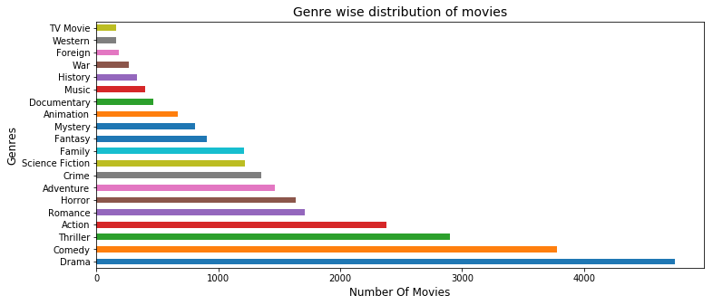

```python
genre_count.plot(kind= 'barh',figsize=(12,5))

plt.title("Genre wise distribution of movies",fontsize=14)
plt.xlabel('Number Of Movies',fontsize=12)
plt.ylabel("Genres",fontsize= 12);
```

Clearly, over the years **drama has been the most popular category of movies** followed by comedy.

### Research Question 2 (How are budget and revenue related?)

```python
# Continue to explore the data to address your additional research
#   questions. Add more headers as needed if you have more questions to
#   investigate.

#Sorting the movies by budget
df[df['budget'].notnull()][['original_title','budget','release_year']].sort_values('budget',ascending=False).head(5)
```

|  | original_title | budget | release_year |
| --- | --- | --- | --- |
| 2245 | Hubble 3D | 425000000 | 2010 |
| 2244 | The Warrior's Way | 425000000 | 2010 |
| 3375 | Pirates of the Caribbean: On Stranger Tides | 380000000 | 2011 |
| 7387 | Pirates of the Caribbean: At World's End | 300000000 | 2007 |
| 14 | Avengers: Age of Ultron | 280000000 | 2015 |

**Hubble 3D** and **The Warrior's Way** are the movies made on maximum budget. They both released in 2010

```python
df[df['revenue'].notnull()][['original_title','revenue','release_year']].sort_values('revenue',ascending=False).head(5)
```

|  | original_title | revenue | release_year |
| --- | --- | --- | --- |
| 1386 | Avatar | 2781505847 | 2009 |
| 3 | Star Wars: The Force Awakens | 2068178225 | 2015 |
| 5231 | Titanic | 1845034188 | 1997 |
| 4361 | The Avengers | 1519557910 | 2012 |
| 0 | Jurassic World | 1513528810 | 2015 |

So, **Avatar** has been the most revenue generating movie. It released in 2009.**Star Wars: The Force Awakens** came close in 2015 but did not surpass the record.

```python
print("The average budget of movies over the years is:",df['budget'].mean())
print("The average revenue earned by movies over the years is:",df['revenue'].mean())
```

```
The average budget of movies over the years is: 21844877.1337
The average revenue earned by movies over the years is: 53603182.3535
```

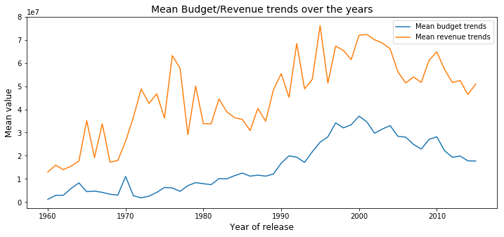

```python
#plotting budget and revenue over the years
budget_yearly=df[df['budget'].notnull()][['release_year','budget']].groupby('release_year').mean()
revenue_yearly=df[df['revenue'].notnull()][['release_year','revenue']].groupby('release_year').mean()

plt.figure(figsize=(12,5))
plt.plot(budget_yearly,label='Mean budget trends')
plt.plot(revenue_yearly,label='Mean revenue trends')

plt.xlabel("Year of release",fontsize=12)
plt.ylabel("Mean value",fontsize=12)
plt.title("Mean Budget/Revenue trends over the years",fontsize=14)
plt.legend(loc='upper right')
plt.show();
```

So, as per the above plot,we find movies on an average have always returned better revenue than there budget. But does, that mean there have been no losses incurred? That can't be possible.Lets try to find out about not so profitable movies.

### Research Question 3 (Which is the most profitable and least profitable movie of all time?)

To calculate profit of a movie, we will create a new column, which calculates profit based on revenue and budget.

```python
#Insering a 'profit' column after 'budget' and 'revenue' col
df.insert(4,'profit',df['revenue']-df['budget'])
df.head(2)
```

|  | id | popularity | budget | revenue | profit | original_title | cast | homepage | director | keywords | runtime | genres | production_companies | release_date | release_year |
| --- | --- | --- | --- | --- | --- | --- | --- | --- | --- | --- | --- | --- | --- | --- | --- |
| 0 | 135397 | 32.985763 | 150000000 | 1513528810 | 1363528810 | Jurassic World | Chris Pratt\|Bryce Dallas Howard\|Irrfan Khan\|Vi... | http://www.jurassicworld.com/ | Colin Trevorrow | monster\|dna\|tyrannosaurus rex\|velociraptor\|island | 124 | Action\|Adventure\|Science Fiction\|Thriller | Universal Studios\|Amblin Entertainment\|Legenda... | 2015-06-09 | 2015 |
| 1 | 76341 | 28.419936 | 150000000 | 378436354 | 228436354 | Mad Max: Fury Road | Tom Hardy\|Charlize Theron\|Hugh Keays-Byrne\|Nic... | http://www.madmaxmovie.com/ | George Miller | future\|chase\|post-apocalyptic\|dystopia\|australia | 120 | Action\|Adventure\|Science Fiction\|Thriller | Village Roadshow Pictures\|Kennedy Miller Produ... | 2015-05-13 | 2015 |

```python
#checking for flop movies
df.query('profit<0')
```

|  | id | popularity | budget | revenue | profit | original_title | cast | homepage | director | keywords | runtime | genres | production_companies | release_date | release_year |
| --- | --- | --- | --- | --- | --- | --- | --- | --- | --- | --- | --- | --- | --- | --- | --- |
| 30 | 280996 | 3.927333 | 61000000 | 29355203 | -31644797 | Mr. Holmes | Ian McKellen\|Milo Parker\|Laura Linney\|Hattie M... | http://www.mrholmesfilm.com/ | Bill Condon | london\|detective\|sherlock holmes | 103 | Mystery\|Drama | BBC Films\|See-Saw Films\|FilmNation Entertainme... | 2015-06-19 | 2015 |
| 57 | 210860 | 2.575711 | 60000000 | 30418560 | -29581440 | Mortdecai | Johnny Depp\|Gwyneth Paltrow\|Ewan McGregor\|Paul... | http://mortdecaithemovie.com/ | David Koepp | based on novel\|painting\|debt\|art dealer\|stolen... | 106 | Comedy\|Adventure | Lionsgate\|Mad Chance\|OddLot Entertainment\|Huay... | 2015-01-21 | 2015 |
| 59 | 201088 | 2.550747 | 70000000 | 17752940 | -52247060 | Blackhat | Chris Hemsworth\|Leehom Wang\|Tang Wei\|Viola Dav... | http://www.legendary.com/film/blackhat/ | Michael Mann | terrorist\|technology\|anti hero\|hacker\|computer... | 133 | Mystery\|Crime\|Action\|Thriller\|Drama | Universal Pictures\|Forward Pass\|Legendary Pict... | 2015-01-13 | 2015 |
| 66 | 205775 | 2.345821 | 100000000 | 93820758 | -6179242 | In the Heart of the Sea | Chris Hemsworth\|Benjamin Walker\|Cillian Murphy... | http://www.intheheartoftheseamovie.com/ | Ron Howard | suicide\|ocean\|sea\|hunger\|shipwreck | 122 | Thriller\|Drama\|Adventure\|Action\|History | Imagine Entertainment\|Spring Creek Productions... | 2015-11-20 | 2015 |
| 72 | 284289 | 2.272044 | 25000000 | 45895 | -24954105 | Beyond the Reach | Michael Douglas\|Jeremy Irvine\|Hanna Mangan Law... | NaN | Jean-Baptiste Léonetti | desert\|hunting | 95 | Thriller | Furthur Films | 2015-04-17 | 2015 |
| 73 | 266647 | 2.234573 | 150000000 | 128388320 | -21611680 | Pan | Levi Miller\|Garrett Hedlund\|Hugh Jackman\|Roone... | NaN | Joe Wright | flying\|magic\|fairy tale\|peter pan\|mermaid | 111 | Adventure\|Family\|Fantasy | Warner Bros.\|Moving Picture Company (MPC)\|Berl... | 2015-09-24 | 2015 |
| 74 | 347096 | 2.165433 | 150000000 | 128388320 | -21611680 | Mythica: The Darkspore | Melanie Stone\|Kevin Sorbo\|Adam Johnson\|Jake St... | http://www.mythicamovie.com/#!blank/wufvh | Anne K. Black | sword\|magic\|sorcery\|necromancer\|woman director | 108 | Action\|Adventure\|Fantasy | Arrowstorm Entertainment | 2015-06-24 | 2015 |
| 75 | 308369 | 2.141506 | 150000000 | 128388320 | -21611680 | Me and Earl and the Dying Girl | Thomas Mann\|RJ Cyler\|Olivia Cooke\|Connie Britt... | http://www.foxsearchlight.com/meandearlandthed... | Alfonso Gomez-Rejon | tattoo\|high school\|leukemia\|friends\|parody | 105 | Comedy\|Drama | Indian Paintbrush | 2015-06-12 | 2015 |
| 84 | 290764 | 2.026651 | 11000000 | 1863315 | -9136685 | Tracers | Marie Avgeropoulos\|Taylor Lautner\|Adam Rayner\|... | http://www.unlimited-movie.com/ | Daniel Benmayor | chinese mafia\|parkour\|new york city\|loan shark... | 94 | Action\|Crime\|Drama | Temple Hill Entertainment\|Senator Film\|Freerun... | 2015-01-15 | 2015 |
| 87 | 287424 | 1.980039 | 4000000 | 187112 | -3812888 | Maggie | Arnold Schwarzenegger\|Abigail Breslin\|Joely Ri... | http://www.maggiethefilm.com/ | Henry Hobson | post-apocalyptic\|dystopia\|zombies | 95 | Horror | Lionsgate\|Grindstone Entertainment Group\|Silve... | 2015-05-08 | 2015 |
| 88 | 301875 | 1.959765 | 4000000 | 2000000 | -2000000 | Equals | Kristen Stewart\|Nicholas Hoult\|Guy Pearce\|Jack... | http://equals-the-movie.com/ | Drake Doremus | illustrator\|sex scene\|near future\|infected\|emo... | 101 | Drama\|Romance\|Science Fiction | Scott Free Productions\|Infinite Frameworks Stu... | 2015-09-04 | 2015 |
| 89 | 181283 | 1.956320 | 50000000 | 3324330 | -46675670 | Child 44 | Tom Hardy\|Gary Oldman\|Noomi Rapace\|Joel Kinnam... | NaN | Daniel Espinosa | murder\|serial killer\|military\|chili\|soviet union | 137 | Crime\|Thriller | Summit Entertainment\|Scott Free Productions\|Wo... | 2015-03-15 | 2015 |
| 106 | 273477 | 1.499614 | 15000000 | 14860766 | -139234 | Scouts Guide to the Zombie Apocalypse | Tye Sheridan\|Logan Miller\|Joey Morgan\|Sarah Du... | http://www.scoutsandzombiesmovie.com/ | Christopher B. Landon | female nudity\|shotgun\|nudity\|strip club\|party | 93 | Comedy\|Horror | Paramount Pictures\|Oops Doughnuts Productions\|... | 2015-10-23 | 2015 |
| 109 | 336004 | 1.449072 | 8900000 | 50136 | -8849864 | Heist | Jeffrey Dean Morgan\|Robert De Niro\|Kate Boswor... | NaN | Scott Mann | casino\|robbery\|bus hijacking\|heist | 93 | Crime\|Action\|Thriller | Emmett/Furla Films\|Silver Plane Films\|Mass Hys... | 2015-11-13 | 2015 |
| 111 | 182560 | 1.443406 | 20000000 | 208588 | -19791412 | Dark Places | Charlize Theron\|Nicholas Hoult\|Christina Hendr... | http://darkplacesmovie.com/ | Gilles Paquet-Brenner | prison\|based on novel\|brother sister relations... | 113 | Drama\|Mystery\|Thriller | Denver and Delilah Productions\|Mandalay Vision... | 2015-03-31 | 2015 |
| 119 | 86828 | 1.360827 | 12000000 | 5189646 | -6810354 | Absolutely Anything | Simon Pegg\|Kate Beckinsale\|Rob Riggle\|Sanjeev ... | NaN | Terry Jones | london\|alien\|teacher\|talking animal\|super powers | 85 | Comedy\|Science Fiction | Premiere Picture\|Bill and Ben Productions\|GFM ... | 2015-06-26 | 2015 |
| 125 | 223485 | 1.329702 | 10000000 | 229094 | -9770906 | Slow West | Michael Fassbender\|Kodi Smit-McPhee\|Ben Mendel... | NaN | John Maclean | fire\|bounty hunter\|shotgun\|horseback riding\|horse | 84 | Romance\|Thriller\|Western | The New Zealand Film Commission\|Film4\|See Saw ... | 2015-04-16 | 2015 |
| 126 | 294016 | 1.316239 | 15000000 | 8235661 | -6764339 | Trumbo | Bryan Cranston\|Diane Lane\|Helen Mirren\|Elle Fa... | NaN | Jay Roach | screenwriter\|communist\|biography\|film history\|... | 124 | Drama | Groundswell Productions\|Inimitable Pictures\|Sh... | 2015-10-27 | 2015 |
| 128 | 309245 | 1.293140 | 19500000 | 2500431 | -16999569 | Mistress America | Greta Gerwig\|Lola Kirke\|Charlie Gillette\|Dean ... | NaN | Noah Baumbach | comedy | 84 | Comedy | RT Features | 2015-08-14 | 2015 |
| 130 | 245706 | 1.284541 | 74000000 | 4719695 | -69280305 | True Story | Jonah Hill\|James Franco\|Felicity Jones\|Maria D... | NaN | Rupert Goold | NaN | 100 | Crime\|Drama\|Mystery | Plan B Entertainment\|Regency Enterprises\|New R... | 2015-04-17 | 2015 |
| 134 | 321751 | 1.245224 | 11000000 | 1702433 | -9297567 | A Perfect Day | Olga Kurylenko\|Benicio del Toro\|Tim Robbins\|MÃ... | NaN | Fernando León de Aranoa | road movie | 106 | Comedy\|Drama | Reposado Producciones\|Televisión Española (T... | 2015-08-28 | 2015 |
| 135 | 266396 | 1.225325 | 40000000 | 10664749 | -29335251 | The Gunman | Sean Penn\|Jasmine Trinca\|Javier Bardem\|Ray Win... | NaN | Pierre Morel | assassin\|hitman | 115 | Action\|Drama\|Crime | StudioCanal\|Silver Pictures\|TF1 Films Producti... | 2015-02-16 | 2015 |
| 139 | 193687 | 1.161812 | 10000000 | 118483 | -9881517 | Z for Zachariah | Margot Robbie\|Chiwetel Ejiofor\|Chris Pine | http://www.facebook.com/ZforZachariah | Craig Zobel | love triangle\|based on novel\|jealousy\|radiatio... | 97 | Drama\|Science Fiction\|Thriller | Palomar Pictures\|Lucky Hat Entertainment\|Silve... | 2015-08-13 | 2015 |
| 140 | 300803 | 1.144808 | 10000000 | 118483 | -9881517 | Dragonheart 3: The Sorcerer's Curse | Julian Morris\|Tamzin Merchant\|Jassa Ahluwalia\|... | NaN | Colin Teague | magic\|wall\|druid\|knight\|dragon | 97 | Action\|Adventure\|Fantasy | Raffaella Productions | 2015-02-24 | 2015 |
| 142 | 228066 | 1.138395 | 40000000 | 34227298 | -5772702 | Victor Frankenstein | James McAvoy\|Daniel Radcliffe\|Jessica Brown Fi... | http://www.foxmovies.com/movies/victor-franken... | Paul McGuigan | london\|frankenstein\|human experiment\|reanimate... | 109 | Drama\|Science Fiction\|Thriller | Twentieth Century Fox Film Corporation\|Davis E... | 2015-11-10 | 2015 |
| 143 | 378373 | 1.128081 | 40000000 | 34227298 | -5772702 | Brothers of the Wind | Manuel Camacho\|Jean Reno\|Tobias Moretti\|Eva Kuen | http://www.terramater.at/cinema/brothers-of-th... | Gerado Olivares\|Otmar Penker | eagle\|learning to fly\|eagle's feather\|father s... | 98 | Adventure\|Drama\|Family | Terra Mater Factual Studios | 2015-12-24 | 2015 |
| 144 | 291270 | 1.125239 | 8000000 | 3759286 | -4240714 | Anomalisa | Jennifer Jason Leigh\|David Thewlis\|Tom Noonan | http://www.anomalisa.com/ | Duke Johnson\|Charlie Kaufman | sex\|depression\|existentialism | 90 | Animation\|Comedy\|Drama\|Romance | Starburns Industries | 2015-12-30 | 2015 |
| 149 | 346808 | 1.041922 | 20000000 | 11472454 | -8527546 | Momentum | Olga Kurylenko\|Morgan Freeman\|James Purefoy\|Je... | NaN | Stephen S. Campanelli | NaN | 96 | Thriller\|Action | Thaba Media\|Azari Media | 2015-08-01 | 2015 |
| 150 | 250124 | 1.038390 | 2000000 | 1477002 | -522998 | The Diary of a Teenage Girl | Bel Powley\|Kristen Wiig\|Alexander Skarsgård\|C... | NaN | Marielle Heller | 1970s\|teenage girl\|older man younger woman rel... | 102 | Drama\|Romance | Caviar Films\|Cold Iron Pictures\|Archer Gray | 2015-08-07 | 2015 |
| 151 | 290637 | 1.036825 | 2000000 | 1477002 | -522998 | Pay the Ghost | Nicolas Cage\|Sarah Wayne Callies\|Veronica Ferr... | NaN | Uli Edel | halloween\|police\|revenge\|burned alive\|children | 94 | Horror\|Thriller | Voltage Films\|Midnight Kitchen Productions | 2015-09-16 | 2015 |
| ... | ... | ... | ... | ... | ... | ... | ... | ... | ... | ... | ... | ... | ... | ... | ... |
| 10728 | 576 | 0.615889 | 6244087 | 638641 | -5605446 | The Wild Bunch | Ernest Borgnine\|William Holden\|Robert Ryan\|Edm... | NaN | Sam Peckinpah | underdog\|bounty hunter\|texas\|mexican revolutio... | 145 | Adventure\|Western | Warner Brothers/Seven Arts | 1969-06-17 | 1969 |
| 10729 | 11485 | 0.589059 | 1500000 | 638641 | -861359 | Take the Money and Run | Woody Allen\|Janet Margolin\|Marcel Hillaire\|Jac... | NaN | Woody Allen | prison\|pickpocket\|jinx\|bad luck\|wedding | 85 | Comedy\|Crime | Palomar Pictures\|American Broadcasting Company... | 1969-08-18 | 1969 |
| 10730 | 11463 | 0.575000 | 12000000 | 638641 | -11361359 | Battle of Britain | Harry Andrews\|Michael Caine\|Trevor Howard\|Curd... | NaN | Guy Hamilton | world war ii\|nazis\|winston churchill\|aviation\|... | 151 | Action\|Drama\|History\|War | Spitfire Productions | 1969-09-15 | 1969 |
| 10731 | 2370 | 0.567962 | 4000000 | 638641 | -3361359 | Topaz | Frederick Stafford\|Dany Robin\|Claude Jade\|Mich... | NaN | Alfred Hitchcock | new york\|cia\|cuba\|cold war\|suspense | 143 | Action\|Drama\|Mystery\|Thriller | Universal Pictures | 1969-12-18 | 1969 |
| 10732 | 13675 | 0.528660 | 4000000 | 638641 | -3361359 | Frosty the Snowman | Jimmy Durante\|Billy De Wolfe\|Jackie Vernon\|Pau... | NaN | Jules Bass\|Arthur Rankin, Jr. | holiday\|christmas | 25 | Family\|Animation\|TV Movie | Rankin/Bass Productions | 1969-12-07 | 1969 |
| 10733 | 28145 | 0.427518 | 4000000 | 638641 | -3361359 | They Shoot Horses, Don't They? | Jane Fonda\|Michael Sarrazin\|Susannah York\|Gig ... | NaN | Sydney Pollack | NaN | 129 | Drama | American Broadcasting Company (ABC)\|Palomar Pi... | 1969-12-10 | 1969 |
| 10734 | 20391 | 0.411816 | 4000000 | 638641 | -3361359 | Paint Your Wagon | Lee Marvin\|Clint Eastwood\|Jean Seberg\|Harve Pr... | NaN | Joshua Logan | mining\|prospector | 158 | Drama\|Action\|Comedy\|Western\|Music | Paramount Pictures\|Malpaso Productions\|Alan Ja... | 1969-10-15 | 1969 |
| 10735 | 14030 | 0.396686 | 4000000 | 638641 | -3361359 | Hello, Dolly! | Barbra Streisand\|Walter Matthau\|Michael Crawfo... | NaN | Gene Kelly | based on play\|based on stage musical\|merchant\|... | 146 | Comedy\|Family\|Music\|Romance | 20th Century Fox | 1969-12-12 | 1969 |
| 10736 | 13384 | 0.337430 | 4000000 | 638641 | -3361359 | Kes | David Bradley\|Freddie Fletcher\|Lynne Perrie\|Co... | NaN | Ken Loach | falcon\|childhood | 110 | Drama | Woodfall Film Productions\|Kestrel Films Ltd. | 1969-11-18 | 1969 |
| 10737 | 18118 | 0.386778 | 4000000 | 638641 | -3361359 | Mackenna's Gold | Gregory Peck\|Omar Sharif\|Camilla Sparv\|Julie N... | NaN | J. Lee Thompson | gold\|marshal | 128 | Action\|Western | Columbia Pictures | 1969-01-01 | 1969 |
| 10738 | 15374 | 0.345405 | 4000000 | 638641 | -3361359 | A Boy Named Charlie Brown | Peter Robbins\|Pamelyn Ferdin\|Glenn Gilger\|Andy... | NaN | Bill Melendez | peanuts | 86 | Animation\|Comedy\|Family | Cinema Center Films\|Lee Mendelson Film Product... | 1969-12-04 | 1969 |
| 10739 | 29228 | 0.338357 | 4000000 | 638641 | -3361359 | The Computer Wore Tennis Shoes | Kurt Russell\|Cesar Romero\|Joe Flynn\|William Sc... | NaN | Robert Butler | NaN | 91 | Comedy\|Family | Walt Disney Pictures | 1969-12-29 | 1969 |
| 10766 | 23916 | 0.591799 | 15000000 | 7185518 | -7814482 | Paradise Alley | Sylvester Stallone\|Lee Canalito\|Armand Assante... | NaN | Sylvester Stallone | dancing\|brother brother relationship\|ice\|ghett... | 107 | Action\|Adventure\|Drama | Image Ten | 1978-09-22 | 1978 |
| 10767 | 13333 | 0.581236 | 15000000 | 7185518 | -7814482 | Game of Death | Bruce Lee\|Kareem Abdul-Jabbar\|Chuck Norris\|Col... | NaN | Robert Clouse | martial arts | 103 | Drama\|Action\|Thriller\|Crime | Golden Harvest Company\|Concord Productions Inc. | 1978-03-22 | 1978 |
| 10768 | 74849 | 0.573763 | 15000000 | 7185518 | -7814482 | The Star Wars Holiday Special | Harrison Ford\|Mark Hamill\|Anthony Daniels\|Carr... | NaN | Steve Binder | holiday\|musical\|space\|jedi\|drunk | 97 | Adventure\|Comedy\|Family\|Science Fiction\|TV Movie | 20th Century Fox Television\|Smith-Hemion Produ... | 1978-12-01 | 1978 |
| 10769 | 26973 | 0.556161 | 15000000 | 7185518 | -7814482 | Pretty Baby | Brooke Shields\|Keith Carradine\|Susan Sarandon\|... | NaN | Louis Malle | prostitute\|photographer\|brothel\|virgin\|new orl... | 110 | Drama\|History | Paramount Pictures\|Synthetic Fur Productions | 1978-04-05 | 1978 |
| 10788 | 24961 | 0.277769 | 24000000 | 21049053 | -2950947 | The Wiz | Diana Ross\|Michael Jackson\|Nipsey Russell\|Ted ... | NaN | Sidney Lumet | melancholy\|little dog\|based on stage musical\|b... | 134 | Adventure\|Family\|Fantasy\|Music\|Science Fiction | Universal Pictures\|Motown Productions | 1978-10-24 | 1978 |
| 10789 | 34193 | 0.076600 | 24000000 | 21049053 | -2950947 | Magic | Anthony Hopkins\|Ann-Margret\|Burgess Meredith\|E... | NaN | Richard Attenborough | alter ego\|ventriloquist\|evil doll\|dummy\|magician | 107 | Drama\|Horror\|Thriller | Twentieth Century Fox Film Corporation\|Joseph ... | 1978-11-08 | 1978 |
| 10800 | 18387 | 0.177276 | 11000000 | 3713768 | -7286232 | Big Wednesday | Jan-Michael Vincent\|William Katt\|Gary Busey\|Pa... | NaN | John Milius | surfing\|sport\|1960s | 120 | Drama | Warner Bros. | 1978-05-02 | 1978 |
| 10801 | 12611 | 0.163770 | 11000000 | 3713768 | -7286232 | The Fury | Kirk Douglas\|John Cassavetes\|Amy Irving\|Carrie... | NaN | Brian De Palma | intelligence\|government agent | 118 | Drama\|Horror\|Science Fiction\|Thriller | Twentieth Century Fox Film Corporation\|Frank Y... | 1978-03-10 | 1978 |
| 10802 | 54000 | 0.227338 | 6727000 | 3713768 | -3013232 | Fedora | William Holden\|Marthe Keller\|Hildegard Knef\|Jo... | NaN | Billy Wilder | hollywood\|actor\|down on his luck | 114 | Drama\|Romance | Société Française de Production (SFP) | 1978-05-30 | 1978 |
| 10803 | 29143 | 0.154407 | 6727000 | 3713768 | -3013232 | Eyes of Laura Mars | Faye Dunaway\|Tommy Lee Jones\|Brad Dourif\|Rene ... | NaN | Irvin Kershner | photographer\|fashion photographer | 104 | Drama\|Horror\|Mystery\|Thriller | Columbia Pictures Corporation | 1978-08-02 | 1978 |
| 10804 | 15867 | 0.149259 | 6727000 | 3713768 | -3013232 | Interiors | Diane Keaton\|Kristin Griffith\|Mary Beth Hurt\|R... | NaN | Woody Allen | independent film | 93 | Drama | NaN | 1978-08-02 | 1978 |
| 10805 | 16241 | 0.138861 | 6727000 | 3713768 | -3013232 | The Boys from Brazil | Gregory Peck\|Laurence Olivier\|James Mason\|Lill... | NaN | Franklin J. Schaffner | paraguay\|mengele\|nazi hunter\|third reich | 125 | Horror\|Drama\|Thriller\|Science Fiction | Producers Circle\|Incorporated Television Company | 1978-10-05 | 1978 |
| 10806 | 24998 | 0.138635 | 6727000 | 3713768 | -3013232 | Gates of Heaven | Lucille Billingsley\|Zella Graham\|Cal Harberts\|... | NaN | Errol Morris | pet\|pet cemetery\|napa valley | 85 | Documentary | NaN | 1978-10-01 | 1978 |
| 10807 | 11623 | 0.130725 | 6727000 | 3713768 | -3013232 | The Medusa Touch | Richard Burton\|Lino Ventura\|Lee Remick\|Harry A... | NaN | Jack Gold | london\|robbery\|supernatural powers\|telekinesis... | 105 | Horror\|Thriller\|Science Fiction | Incorporated Television Company (ITC)\|Coatesgold | 1978-04-13 | 1978 |
| 10808 | 40060 | 0.129123 | 6727000 | 3713768 | -3013232 | The Manitou | Tony Curtis\|Michael Ansara\|Susan Strasberg\|Ste... | NaN | William Girdler | female nudity\|based on novel\|nudity\|tarot card... | 104 | Horror | Melvin Simon Productions\|Mid-America Pictures\|... | 1978-04-28 | 1978 |
| 10809 | 31428 | 0.128231 | 6727000 | 3713768 | -3013232 | Someone's Watching Me! | Lauren Hutton\|David Birney\|Adrienne Barbeau\|Le... | NaN | John Carpenter | stalker\|suspense\|stalking\|made for television | 97 | Horror\|Mystery\|TV Movie\|Thriller | Warner Bros. Television | 1978-11-27 | 1978 |
| 10817 | 13963 | 0.064029 | 3000000 | 321952 | -2678048 | The Last Waltz | Robbie Robertson\|Rick Danko\|Levon Helm\|Richard... | http://www.mgm.com/#/our-titles/1092/The-Last-... | Martin Scorsese | 1970s\|music | 117 | Documentary\|Music | FM Productions\|Last Waltz Inc. | 1978-05-01 | 1978 |
| 10818 | 39995 | 0.047645 | 3000000 | 321952 | -2678048 | Long Weekend | John Hargreaves\|Briony Behets\|Mike McEwen\|Roy ... | NaN | Colin Eggleston | beach\|camping\|attack\|nature | 92 | Horror\|Thriller\|Mystery | The Australian Film Commission\|Victorian Film\|... | 1978-10-14 | 1978 |

4517 rows × 15 columns

So, there are 4517 movies that have incurred losses.

```python
#Checking for highest profit making movie
df[df['profit'] == df['profit'].max()]
```

|  | id | popularity | budget | revenue | profit | original_title | cast | homepage | director | keywords | runtime | genres | production_companies | release_date | release_year |
| --- | --- | --- | --- | --- | --- | --- | --- | --- | --- | --- | --- | --- | --- | --- | --- |
| 1386 | 19995 | 9.432768 | 237000000 | 2781505847 | 2544505847 | Avatar | Sam Worthington\|Zoe Saldana\|Sigourney Weaver\|S... | http://www.avatarmovie.com/ | James Cameron | culture clash\|future\|space war\|space colony\|so... | 162 | Action\|Adventure\|Fantasy\|Science Fiction | Ingenious Film Partners\|Twentieth Century Fox ... | 2009-12-10 | 2009 |

```python
# checking for lowest profit making movie
df[df['profit'] == df['profit'].min()]
```

|  | id | popularity | budget | revenue | profit | original_title | cast | homepage | director | keywords | runtime | genres | production_companies | release_date | release_year |
| --- | --- | --- | --- | --- | --- | --- | --- | --- | --- | --- | --- | --- | --- | --- | --- |
| 2244 | 46528 | 0.250540 | 425000000 | 11087569 | -413912431 | The Warrior's Way | Kate Bosworth\|Jang Dong-gun\|Geoffrey Rush\|Dann... | http://www.iamrogue.com/thewarriorsway | Sngmoo Lee | assassin\|small town\|revenge\|deception\|super speed | 100 | Adventure\|Fantasy\|Action\|Western\|Thriller | Boram Entertainment Inc. | 2010-12-02 | 2010 |
| 2245 | 44992 | 0.377897 | 425000000 | 11087569 | -413912431 | Hubble 3D | Leonardo DiCaprio | NaN | Toni Myers | space\|imax\|space shuttle\|woman director\|3d | 44 | Documentary | Warner Bros.\|IMAX Space Ltd. | 2010-03-19 | 2010 |

So, there are no changed patterns here, most profitable movie remains **Avatar** and least profitable movies remain **The Warrior's Way** and **Hubble 3D**. There is no new information so far here.Lets check is there any trend for movies that have incurred losses. **Which year has had the most number of losses?**

### Research Question 4 (Which year has seen maximum losses and what are the average number of flop movies per year?)

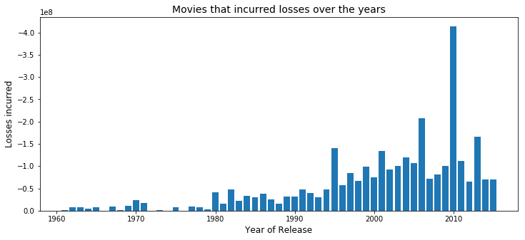

```python
#Analysing flop movies
movies_losses=df['profit'][df['profit']<0]
movies_release=df['release_year'][df['profit']<0]

plt.figure(figsize=(12,5))

plt.bar(movies_release,movies_losses)
plt.gca().invert_yaxis()
plt.xlabel('Year of Release',fontsize=12)
plt.ylabel('Losses incurred',fontsize=12)
plt.title('Movies that incurred losses over the years',fontsize=14)

plt.show();
```

```python
df[df['release_year']==2006].sort_values(by='profit')
```

|  | id | popularity | budget | revenue | profit | original_title | cast | homepage | director | keywords | runtime | genres | production_companies | release_date | release_year |
| --- | --- | --- | --- | --- | --- | --- | --- | --- | --- | --- | --- | --- | --- | --- | --- |
| 6889 | 13650 | 0.146450 | 210000000 | 2043704 | -207956296 | Delirious | Steve Buscemi\|Michael Pitt\|Alison Lohman\|Gina ... | NaN | Tom DiCillo | NaN | 107 | Comedy\|Drama\|Romance | Peace Arch Entertainment Group\|Artina Films\|Th... | 2006-09-26 | 2006 |
| 6887 | 15664 | 0.154600 | 210000000 | 2043704 | -207956296 | Right at Your Door | Mary McCormack\|Rory Cochrane\|Tony Perez\|Scotty... | NaN | Chris Gorak | post-apocalyptic | 96 | Drama\|Thriller | NaN | 2006-01-23 | 2006 |
| 6888 | 15590 | 0.150038 | 210000000 | 2043704 | -207956296 | The Prince & Me 2: The Royal Wedding | Luke Mably\|Kam Heskin\|Maryam d'Abo\|Clemency Bu... | NaN | Catherine Cyran | prince\|bride\|sequel\|royalty\|wedding | 96 | Family\|Comedy\|Romance | Capital Arts Entertainment\|Sobini Films | 2006-02-21 | 2006 |
| 6707 | 9986 | 0.536631 | 85000000 | 144 | -84999856 | Charlotte's Web | Julia Roberts\|Steve Buscemi\|John Cleese\|Oprah ... | NaN | Gary Winick | hero\|barn\|spider\|pig\|egg | 97 | Comedy\|Family\|Fantasy | Paramount Pictures\|Kerner Entertainment Company | 2006-12-15 | 2006 |
| 6579 | 7457 | 1.568120 | 100000000 | 15309302 | -84690698 | Alpha Dog | Bruce Willis\|Matthew Barry\|Emile Hirsch\|Justin... | NaN | Nick Cassavetes | sex\|hostage drama\|kidnapping and murder\|swimmi... | 122 | Crime\|Drama | A-Mark Entertainment | 2006-01-27 | 2006 |
| 6590 | 11619 | 1.390297 | 149000000 | 64459316 | -84540684 | Flushed Away | Hugh Jackman\|Kate Winslet\|Ian McKellen\|Jean Re... | http://www.dreamworksanimation.com/flushed/ | David Bowers\|Sam Fell | london\|underworld\|return\|ship\|frog | 85 | Adventure\|Animation\|Comedy\|Family | Aardman Animations\|DreamWorks Animation | 2006-10-22 | 2006 |
| 6682 | 10063 | 0.632401 | 70000000 | 1675484 | -68324516 | The Breed | Michelle Rodriguez\|Taryn Manning\|Eric Lively\|O... | NaN | Nicholas Mastandrea | exotic island\|vacation\|dog | 90 | Horror | ApolloProMovie\|First Look Pictures | 2006-05-17 | 2006 |
| 6624 | 1717 | 0.928134 | 55000000 | 9450897 | -45549103 | All the King's Men | Sean Penn\|Jude Law\|Kate Winslet\|James Gandolfi... | http://www.sonypictures.com/homevideo/alltheki... | Steven Zaillian | corruption\|journalist\|based on novel\|blackmail... | 125 | Drama\|Thriller | Columbia Pictures Corporation\|Rising Star\|Rela... | 2006-09-10 | 2006 |
| 6591 | 9904 | 1.363623 | 80000000 | 37384046 | -42615954 | The Wild | Kiefer Sutherland\|Jim Belushi\|Eddie Izzard\|Jan... | http://www.disney.com/thewild | Steve 'Spaz' Williams | new york\|africa\|lion\|zoo\|wild | 94 | Family\|Animation | Walt Disney Pictures\|Contrafilm\|C.O.R.E. Featu... | 2006-03-06 | 2006 |
| 6735 | 9664 | 0.435451 | 60000000 | 17800000 | -42200000 | Flyboys | James Franco\|Scott Hazell\|Mac McDonald\|Philip ... | NaN | Tony Bill | world war i\|biplane | 140 | Action\|Adventure\|Drama\|History\|Romance | Ingenious Film Partners\|Electric Entertainment... | 2006-09-22 | 2006 |
| 6692 | 10115 | 0.602140 | 50000000 | 9448082 | -40551918 | Stick It | Jeff Bridges\|Missy Peregrym\|Vanessa Lengies\|Ma... | NaN | Jessica Bendinger | gymnastics\|trainer\|puberty\|training\|sport | 105 | Comedy\|Drama | Spyglass Entertainment\|Touchstone Pictures\|Kal... | 2006-04-21 | 2006 |
| 6690 | 11515 | 0.606808 | 50000000 | 9448082 | -40551918 | Goya's Ghosts | Javier Bardem\|Natalie Portman\|Stellan Skarsgå... | NaN | MiloÅ¡ Forman | rape\|verlies\|heresy\|religion and supernatural\|... | 114 | Drama | Kanzaman\|The Saul Zaentz Company\|Antena 3 Tele... | 2006-11-08 | 2006 |
| 6691 | 17700 | 0.604070 | 50000000 | 9448082 | -40551918 | Deep Sea 3D | Johnny Depp\|Kate Winslet | NaN | Howard Hall | octopus\|sea turtle\|imax\|shrimp\|manta ray | 41 | Documentary | IMAX\|Warner Bros. | 2006-03-03 | 2006 |
| 6636 | 14784 | 0.854533 | 37665000 | 3669465 | -33995535 | The Fall | Catinca Untaru\|Lee Pace\|Justine Waddell\|Kim Uy... | http://www.thefallthemovie.com/ | Tarsem Singh | fictional place\|indian\|morphine\|darwin\|imagina... | 117 | Adventure\|Fantasy\|Drama | Roadside Attractions\|Absolute Entertainment\|Go... | 2006-09-09 | 2006 |
| 6799 | 9697 | 0.298124 | 75000000 | 42285169 | -32714831 | Lady in the Water | Paul Giamatti\|Jeffrey Wright\|Bob Balaban\|Sarit... | NaN | M. Night Shyamalan | fortune teller\|religion and supernatural\|super... | 110 | Drama\|Thriller\|Fantasy\|Mystery | Legendary Pictures\|Warner Bros.\|Blinding Edge ... | 2006-07-21 | 2006 |
| 6627 | 3093 | 0.916551 | 70000000 | 38629478 | -31370522 | Basic Instinct 2 | Sharon Stone\|David Morrissey\|Charlotte Ramplin... | NaN | Michael Caton-Jones | male nudity\|sex\|legs\|soho london\|playing god | 114 | Crime\|Mystery\|Thriller | Intermedia Films\|Kanzaman\|C-2 Pictures\|IMF Int... | 2006-03-29 | 2006 |
| 6678 | 4441 | 0.642848 | 33000000 | 2077763 | -30922237 | Candy | Abbie Cornish\|Heath Ledger\|Geoffrey Rush\|Tony ... | http://www.dendyfilms.com.au/candy/ | Neil Armfield | junkie\|methadone programme\|heroin\|artist\|cold ... | 116 | Drama\|Romance | Film Finance Group\|The New South Wales Film an... | 2006-02-15 | 2006 |
| 6639 | 7512 | 0.848086 | 30000000 | 495303 | -29504697 | Idiocracy | Luke Wilson\|Maya Rudolph\|Dax Shepard\|Terry Cre... | NaN | Mike Judge | prostitute\|capitalism\|u.s. president\|arena\|con... | 84 | Adventure\|Comedy\|Science Fiction | Twentieth Century Fox Film Corporation\|Ternion... | 2006-09-01 | 2006 |
| 6685 | 11652 | 0.621317 | 85000000 | 57806952 | -27193048 | Invincible | Mark Wahlberg\|Greg Kinnear\|Elizabeth Banks\|Kev... | NaN | Ericson Core | american football\|sports team\|bad luck\|advance... | 105 | Drama | Walt Disney Pictures | 2006-08-25 | 2006 |
| 6734 | 182 | 0.437529 | 32000000 | 5914908 | -26085092 | The Good German | George Clooney\|Cate Blanchett\|Tobey Maguire\|To... | http://www.the-good-german.de | Steven Soderbergh | berlin\|corruption\|nazi background\|love of one'... | 108 | War\|Crime\|Drama\|Mystery\|Romance | Warner Bros.\|Section Eight Productions\|Sunset ... | 2006-12-08 | 2006 |
| 6802 | 10961 | 0.293239 | 26000000 | 69136 | -25930864 | Behind the Mask: The Rise of Leslie Vernon | Nathan Baesel\|Angela Goethals\|Robert Englund\|S... | NaN | Scott Glosserman | career\|victim of murder\|idol\|filmteam\|serial k... | 92 | Comedy\|Horror\|Thriller | NaN | 2006-01-01 | 2006 |
| 6604 | 1247 | 1.182280 | 85000000 | 59908565 | -25091435 | The Good Shepherd | Matt Damon\|Angelina Jolie\|Alec Baldwin\|Tammy B... | http://www.thegoodshepherdmovie.com/ | Robert De Niro | london\|berlin\|usa\|spy\|cia | 167 | Drama\|Thriller\|History | Universal Pictures\|American Zoetrope\|Morgan Cr... | 2006-12-11 | 2006 |
| 6809 | 3603 | 0.440741 | 30000000 | 4946225 | -25053775 | Black Sheep | Nathan Meister\|Peter Feeney\|Danielle Mason\|Jam... | http://www.blacksheep-themovie.com/ | Jonathan King | new zealand\|sheep\|animal horror | 87 | Horror\|Comedy | New Zealand Film Commission\|Live Stock Films | 2006-09-09 | 2006 |
| 6810 | 10085 | 0.276246 | 30000000 | 4946225 | -25053775 | Unrest | Joshua Alba\|Scot Davis\|Corri English\|Marisa Pe... | NaN | Jason Todd Ipson | prostitute\|murder of prostitute\|medical examin... | 88 | Horror | Asgaard Entertainment\|YMIR Productions | 2006-10-22 | 2006 |
| 6610 | 3683 | 1.103135 | 90000000 | 65900249 | -24099751 | Flags of Our Fathers | Ryan Phillippe\|Adam Beach\|Jesse Bradford\|John ... | NaN | Clint Eastwood | world war ii\|dying and death\|pacific\|iwo jima\|... | 132 | War\|Drama\|History | DreamWorks SKG\|Amblin Entertainment\|Malpaso Pr... | 2006-10-19 | 2006 |
| 6634 | 15860 | 0.873357 | 37665000 | 14655628 | -23009372 | Lung fu moon | Donnie Yen\|Nicholas Tse\|Shawn Yue\|Dong Jie\|Li ... | NaN | Wilson Yip | kung fu | 94 | Action\|Thriller | NaN | 2006-07-27 | 2006 |
| 6633 | 9959 | 0.875630 | 37665000 | 14655628 | -23009372 | Freedomland | Samuel L. Jackson\|Julianne Moore\|Edie Falco\|Au... | http://www.sonypictures.com/homevideo/freedoml... | Joe Roth | black people\|new jersey\|lie\|psychological stre... | 113 | Drama\|Thriller\|Crime\|Mystery | Scott Rudin Productions\|Revolution Studios | 2006-02-17 | 2006 |
| 6713 | 3602 | 0.520258 | 35000000 | 12506188 | -22493812 | I'll Always Know What You Did Last Summer | Brooke Nevin\|David Paetkau\|K.C. Clyde\|Seth Pac... | NaN | Sylvain White | colorado\|fireworks\|baseball bat\|chainsaw\|cell ... | 92 | Horror | Screen Gems | 2006-06-24 | 2006 |
| 6711 | 13285 | 0.523882 | 35000000 | 12506188 | -22493812 | Barbie Fairytopia: Mermaidia | Kelly Sheridan\|Lee Tockar\|Christopher Gaze\|Kat... | NaN | William Lau\|Walter P. Martishius | NaN | 75 | Animation\|Family\|Adventure\|Fantasy | NaN | 2006-03-14 | 2006 |
| 6710 | 18843 | 0.526426 | 35000000 | 12506188 | -22493812 | Dr. Dolittle 3 | Kyla Pratt\|Kristen Wilson\|Tara Wilson\|Walker H... | NaN | Rich Thorne | NaN | 95 | Comedy\|Family\|Fantasy | NaN | 2006-04-25 | 2006 |
| ... | ... | ... | ... | ... | ... | ... | ... | ... | ... | ... | ... | ... | ... | ... | ... |
| 6592 | 7551 | 1.350070 | 75000000 | 180557550 | 105557550 | DéjÃ Vu | Denzel Washington\|Paula Patton\|Val Kilmer\|Jim ... | NaN | Tony Scott | deja vu\|new orleans\|time travel\|investigator\|f... | 126 | Action\|Thriller\|Science Fiction | Jerry Bruckheimer Films\|Scott Free Productions... | 2006-11-21 | 2006 |
| 6731 | 9520 | 0.449640 | 15000000 | 123384128 | 108384128 | The Thief Lord | Aaron Taylor-Johnson\|Jasper Harris\|Rollo Weeks... | NaN | Richard Claus | venice\|detective\|secret\|island\|children gang | 98 | Adventure\|Family\|Foreign | NaN | 2006-01-04 | 2006 |
| 6730 | 1165 | 0.451217 | 15000000 | 123384128 | 108384128 | The Queen | Helen Mirren\|Michael Sheen\|James Cromwell\|Sylv... | http://www.thequeenmovie.co.uk/ | Stephen Frears | upper class\|loss of mother\|great britain\|sadne... | 103 | Drama | BIM Distribuzione\|Granada Film Productions\|Sco... | 2006-09-15 | 2006 |
| 6564 | 1581 | 2.606305 | 85000000 | 194168700 | 109168700 | The Holiday | Cameron Diaz\|Kate Winslet\|Jude Law\|Jack Black\|... | http://www.sonypictures.com/movies/theholiday/ | Nancy Meyers | holiday\|london\|film making\|christmas party\|cou... | 136 | Comedy\|Romance | Columbia Pictures\|Universal Pictures\|Waverly F... | 2006-12-08 | 2006 |
| 6567 | 1164 | 2.160936 | 25000000 | 135330182 | 110330182 | Babel | Brad Pitt\|Cate Blanchett\|Gael García Bernal\|R... | NaN | Alejandro González Iñárritu | terror\|loss of mother\|gun\|morocco\|deaf-mute | 143 | Drama | Paramount Vantage\|Media Rights Capital\|Anonymo... | 2006-09-08 | 2006 |
| 6672 | 25676 | 0.682902 | 85000000 | 197309027 | 112309027 | Bo bui gai wak | Jackie Chan\|Louis Koo\|Michael Hui\|Teresa Carpi... | NaN | Benny Chan | kidnapping | 126 | Drama\|Action\|Comedy | Emperor Motion Pictures | 2006-09-28 | 2006 |
| 6671 | 7484 | 0.685491 | 85000000 | 197309027 | 112309027 | Open Season | Martin Lawrence\|Ashton Kutcher\|Gary Sinise\|Deb... | http://www.sonypictures.com/movies/openseason/ | Roger Allers\|Jill Culton\|Anthony Stacchi | hunter\|mountains\|garage\|grizzly bear\|bunny | 83 | Adventure\|Animation\|Family | Sony Pictures Animation | 2006-09-29 | 2006 |
| 6570 | 1452 | 1.957331 | 270000000 | 391081192 | 121081192 | Superman Returns | Brandon Routh\|Kevin Spacey\|Kate Bosworth\|James... | http://www.superman.com | Bryan Singer | saving the world\|dc comics\|invulnerability\|seq... | 154 | Adventure\|Fantasy\|Action\|Science Fiction | DC Comics\|Legendary Pictures\|Warner Bros.\|Bad ... | 2006-06-28 | 2006 |
| 6602 | 9513 | 1.207359 | 15000000 | 141702264 | 126702264 | Garfield 2 | Bill Murray\|Jennifer Love Hewitt\|Billy Connoll... | NaN | Tim Hill | london\|mistake in person\|luxury\|wretch\|kater | 78 | Animation\|Comedy\|Family | Twentieth Century Fox Film Corporation\|Dune En... | 2006-06-15 | 2006 |
| 6588 | 1246 | 1.409773 | 24000000 | 155721132 | 131721132 | Rocky Balboa | Sylvester Stallone\|Burt Young\|Milo Ventimiglia... | http://www.rocky.com/ | Sylvester Stallone | philadelphia\|transporter\|fight\|love of one's l... | 102 | Drama | Columbia Pictures\|Revolution Studios\|Rogue Mar... | 2006-12-20 | 2006 |
| 6595 | 4257 | 1.241836 | 45000000 | 178262620 | 133262620 | Scary Movie 4 | Anna Faris\|Regina Hall\|Craig Bierko\|Bill Pullm... | NaN | David Zucker | haunted house\|alien life-form\|riesen-ipod | 83 | Comedy | Dimension Films | 2006-04-13 | 2006 |
| 6597 | 10947 | 1.223392 | 4200000 | 140175006 | 135975006 | High School Musical | Zac Efron\|Vanessa Hudgens\|Ashley Tisdale\|Lucas... | http://tv.disney.go.com/disneychannel/original... | Kenny Ortega | becoming an adult\|musical\|music\|high school\|sc... | 98 | Comedy\|Drama\|Family\|Music\|TV Movie | Disney Channel | 2006-01-20 | 2006 |
| 6575 | 388 | 1.747256 | 45000000 | 184376254 | 139376254 | Inside Man | Denzel Washington\|Clive Owen\|Jodie Foster\|Chri... | http://theinsideman.net | Spike Lee | bank manager\|kidnapper\|nazi background\|blackma... | 129 | Crime\|Drama\|Thriller | Imagine Entertainment\|Universal Pictures | 2006-03-23 | 2006 |
| 6593 | 2486 | 1.296272 | 100000000 | 249288105 | 149288105 | Eragon | Ed Speleers\|Jeremy Irons\|Sienna Guillory\|Rober... | http://www.eragonmovie.com/ | Stefen Fangmeier | based on novel\|mythical creature\|dragon\|fantas... | 104 | Fantasy\|Action\|Adventure\|Family | Ingenious Film Partners\|Twentieth Century Fox ... | 2006-12-14 | 2006 |
| 6574 | 9767 | 1.769350 | 52000000 | 204999686 | 152999686 | The Break-Up | Vince Vaughn\|Jennifer Aniston\|Joey Lauren Adam... | https://www.uphe.com/movies/the-break-up | Peyton Reed | bowling\|chicago\|american football\|flat\|baseball | 106 | Romance\|Comedy | Universal Pictures\|Mosaic Media Group\|Wild Wes... | 2006-06-01 | 2006 |
| 6638 | 214 | 0.849096 | 10000000 | 163876815 | 153876815 | Saw III | Tobin Bell\|Shawnee Smith\|Angus Macfadyen\|Bahar... | NaN | Darren Lynn Bousman | brain tumor\|nudity\|suffocation\|mutilation\|seve... | 108 | Horror\|Thriller\|Crime | Lions Gate Films\|Twisted Pictures\|Evolution En... | 2006-10-27 | 2006 |
| 6573 | 10010 | 1.852503 | 82500000 | 237681299 | 155181299 | Brother Bear 2 | Mandy Moore\|Jeremy Suarez\|Dave Thomas\|Rick Mor... | NaN | Ben Gluck | grizzly bear\|human being-animal relationship\|h... | 75 | Animation\|Comedy\|Family\|Adventure\|Fantasy | Walt Disney Pictures\|DisneyToon Studios | 2006-08-16 | 2006 |
| 6572 | 9339 | 1.888746 | 82500000 | 237681299 | 155181299 | Click | Adam Sandler\|Kate Beckinsale\|Christopher Walke... | NaN | Frank Coraci | regret\|workaholic\|heart attack\|architect\|dying... | 107 | Comedy\|Drama\|Fantasy\|Romance | Original Film\|Columbia Pictures Corporation\|Re... | 2006-06-22 | 2006 |
| 6563 | 1422 | 2.819750 | 90000000 | 289847354 | 199847354 | The Departed | Leonardo DiCaprio\|Matt Damon\|Jack Nicholson\|Ma... | http://thedeparted.warnerbros.com/ | Martin Scorsese | undercover\|boston\|police\|friends\|mafia | 151 | Drama\|Thriller\|Crime | Vertigo Entertainment\|Media Asia Films\|Warner ... | 2006-10-05 | 2006 |
| 6571 | 496 | 1.930735 | 18000000 | 261572744 | 243572744 | Borat: Cultural Learnings of America for Make ... | Sacha Baron Cohen\|Ken Davitian\|Luenell\|Pamela ... | http://www.boratmovie.com/ | Larry Charles | male nudity\|usa\|california\|prostitute\|journalist | 82 | Comedy | Twentieth Century Fox Film Corporation\|Four By... | 2006-11-02 | 2006 |
| 6561 | 956 | 3.098051 | 150000000 | 397850012 | 247850012 | Mission: Impossible III | Tom Cruise\|Philip Seymour Hoffman\|Ving Rhames\|... | http://www.missionimpossible.com/ | J.J. Abrams | berlin\|cia\|vatican\|white house\|secret identity | 126 | Adventure\|Action\|Thriller | Paramount Pictures\|Cruise/Wagner Productions\|S... | 2006-05-03 | 2006 |
| 6631 | 1402 | 0.890909 | 55000000 | 307077295 | 252077295 | The Pursuit of Happyness | Will Smith\|Jaden Smith\|Thandie Newton\|Brian Ho... | http://www.sonypictures.com/homevideo/thepursu... | Gabriele Muccino | san francisco\|single parent\|homeless person\|bu... | 117 | Drama | Columbia Pictures Corporation\|Escape Artists\|R... | 2006-12-14 | 2006 |
| 6587 | 9836 | 1.411147 | 100000000 | 384335608 | 284335608 | Happy Feet | Lombardo Boyar\|Robin Williams\|Johnny A. Sanche... | NaN | George Miller | ocean\|fish\|zoo\|penguin\|tap dancing | 108 | Music\|Animation\|Comedy\|Family | Village Roadshow Pictures\|Kennedy Miller Produ... | 2006-11-16 | 2006 |
| 6562 | 350 | 3.031430 | 35000000 | 326551094 | 291551094 | The Devil Wears Prada | Meryl Streep\|Anne Hathaway\|Emily Blunt\|Stanley... | http://www.devilwearspradamovie.com/ | David Frankel | paris\|journalist\|journalism\|world of fasion\|fa... | 109 | Comedy\|Drama\|Romance | Twentieth Century Fox Film Corporation\|Dune En... | 2006-06-30 | 2006 |
| 6556 | 920 | 3.941265 | 120000000 | 461983149 | 341983149 | Cars | Owen Wilson\|Paul Newman\|Bonnie Hunt\|Larry the ... | http://disney.go.com/disneyvideos/animatedfilm... | John Lasseter\|Joe Ranft | car race\|car journey\|village and town\|road\|auto | 117 | Animation\|Adventure\|Comedy\|Family | Walt Disney Pictures\|Pixar Animation Studios | 2006-06-08 | 2006 |
| 6557 | 36557 | 3.789580 | 150000000 | 599045960 | 449045960 | Casino Royale | Daniel Craig\|Eva Green\|Mads Mikkelsen\|Judi Den... | http://www.mgm.com/#/our-titles/233/Casino-Roy... | Martin Campbell | italy\|poker\|casino\|terrorist\|banker | 144 | Adventure\|Action\|Thriller | Eon Productions | 2006-11-14 | 2006 |
| 6566 | 1593 | 2.313345 | 110000000 | 574480841 | 464480841 | Night at the Museum | Ben Stiller\|Jake Cherry\|Carla Gugino\|Robin Wil... | NaN | Shawn Levy | sunrise\|indian\|museum\|skeleton\|chaos | 108 | Action\|Adventure\|Comedy\|Family\|Fantasy | Ingenious Film Partners\|Twentieth Century Fox ... | 2006-10-20 | 2006 |
| 6560 | 950 | 3.145562 | 80000000 | 660940780 | 580940780 | Ice Age: The Meltdown | Ray Romano\|John Leguizamo\|Denis Leary\|Queen La... | http://www.iceagemovies.com/films/ice-age-the-... | Carlos Saldanha | mammoth\|sloth\|ice age\|barrier ice\|ice melting | 91 | Animation\|Family\|Comedy\|Adventure | Blue Sky Studios\|Twentieth Century Fox Animation | 2006-03-23 | 2006 |
| 6558 | 591 | 3.655536 | 125000000 | 758239851 | 633239851 | The Da Vinci Code | Tom Hanks\|Audrey Tautou\|Ian McKellen\|Paul Bett... | http://www.sonypictures.com/homevideo/thedavin... | Ron Howard | paris\|holy grail\|christianity\|monk\|zurich | 149 | Thriller\|Mystery | Columbia Pictures\|Imagine Entertainment\|Skylar... | 2006-05-17 | 2006 |
| 6555 | 58 | 4.205992 | 200000000 | 1065659812 | 865659812 | Pirates of the Caribbean: Dead Man's Chest | Johnny Depp\|Orlando Bloom\|Keira Knightley\|Bill... | http://disney.go.com/disneypictures/pirates/ | Gore Verbinski | witch\|fortune teller\|bondage\|exotic island\|mon... | 151 | Adventure\|Fantasy\|Action | Walt Disney Pictures\|Jerry Bruckheimer Films\|S... | 2006-06-20 | 2006 |

404 rows × 15 columns

So there are 3 movies that have been huge flops this year and that is why, this is the second poor year.

```python
#Computing loss % of movies each year.

df_losses=df[df["profit"] <0].groupby("release_year")
df_losses['profit'].count()

df_total=df.groupby("release_year")
df_total['profit'].count()

print("On an average below are the % of movies that flop each year")
print(round((df_losses['profit'].count()/df_total['profit'].count())*100,2))
```

```
On an average below are the % of movies that flop each year
release_year
1960      NaN
1961     3.23
1962     3.12
1963    17.65
1964    38.10
1965     8.57
1966      NaN
1967     7.89
1968    10.53
1969    40.00
1970    47.50
1971     1.82
1972      NaN
```

[output cut: 44 more lines]

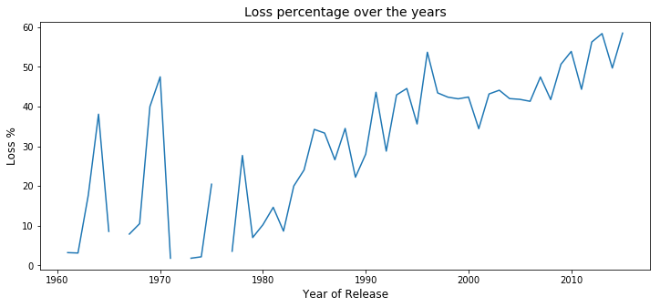

```python
prop_losses=(df_losses['profit'].count()/df_total['profit'].count())*100

plt.figure(figsize=(12,5))

plt.plot(prop_losses)
plt.xlabel('Year of Release',fontsize=12)
plt.ylabel('Loss %',fontsize=12)
plt.title('Loss percentage over the years',fontsize=14)

plt.show()
```

So the rate of movies being flopped has been gradually increasing after 1980. Though there was an unusual peak in 1970 and 1996.

### Research Question 5 ( Which has been the most succesful year so far?)

```python
movie_yearlyprofit=df.groupby('release_year')['profit'].sum().sort_values(ascending=False)
movie_yearlyprofit.head(8)
```

```
release_year
2013    21151062261
2015    20500354028
2014    19510752486
2011    18650179615
2012    18521033614
2009    17897804023
2010    17408329561
2008    13990109705
Name: profit, dtype: int64
```

So **2013 has been the most succesful year in terms of profit**. Surprisingly, its not 2009 when Avatar was released.

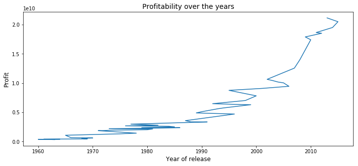

```python
plt.figure(figsize=(12,5))
plt.plot(movie_yearlyprofit)
plt.xlabel('Year of release',fontsize=12)
plt.ylabel('Profit',fontsize=12)
plt.title('Profitability over the years',fontsize=14)
plt.show()
```

Profitability in movies have been increasing year by year.

### Research Question 6 (Which actor/actress has done most number of succesful movies?)

Moving forward in the anlaysis, to measure the success of movies, we will be creating another dataframe, which has the dataset of only successful movies i.e movies that have made any profit.For that,I am putting movies in this dataset with profit>0

```python
# Only considering profitable movies.

df_profitable_movies=df[df['profit']>0]
```

```python
df_profitable_movies['budget'].mean()
```

```
23471535.462133419
```

```python
df_profitable_movies['revenue'].mean()
```

```
87295638.921044156
```

```python
# Splitting the cast column
cast_data = df_profitable_movies['cast'].str.cat(sep = '|')
cast_data = pd.Series(cast_data.split('|'))

#Counting by cast
cast_count = cast_data.value_counts(ascending = False)
cast_count.head(5)
```

```
Robert De Niro       49
Tom Hanks            41
Samuel L. Jackson    41
Michael Caine        39
Bruce Willis         38
dtype: int64
```

**Robert De Niro has done the most number of succesful movies**

### Research Question 7 (How are runtimes of movies changing over the years? Is there any corelation between runtime and popularity?)

```python
yearly_runtimes=df_profitable_movies.groupby('release_year')['runtime'].mean().sort_index()
yearly_runtimes
```

```
release_year
1960    110.656250
1961    118.700000
1962    122.612903
1963    109.785714
1964    112.846154
1965    115.687500
1966    106.891304
1967    107.314286
1968    115.735294
1969    105.833333
1970    121.857143
1971    107.555556
1972    101.950000
1973    103.648148
```

[output cut: 43 more lines]

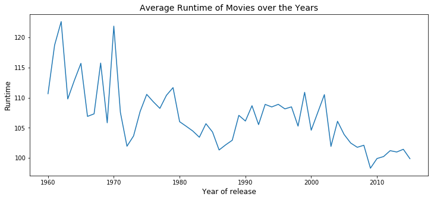

```python
plt.figure(figsize=(12,5))
plt.plot(yearly_runtimes)
plt.title('Average Runtime of Movies over the Years',fontsize=14)
plt.xlabel('Year of release',fontsize=12)
plt.ylabel('Runtime',fontsize=12)
plt.show()
```

Clearly the average runtime of movies have decreased significantly from 122mins in 1962 to 99 minutes in 2015.As the profotability has also increased over time we can say, that now shorter duration movies are more liked by people.

### Research Question 8 (What are the popularity trends over the years?)

```python
#Checking for the film with max popularity score
df_profitable_movies[df_profitable_movies['popularity']==df_profitable_movies['popularity'].max()]
```

|  | id | popularity | budget | revenue | profit | original_title | cast | homepage | director | keywords | runtime | genres | production_companies | release_date | release_year |
| --- | --- | --- | --- | --- | --- | --- | --- | --- | --- | --- | --- | --- | --- | --- | --- |
| 0 | 135397 | 32.985763 | 150000000 | 1513528810 | 1363528810 | Jurassic World | Chris Pratt\|Bryce Dallas Howard\|Irrfan Khan\|Vi... | http://www.jurassicworld.com/ | Colin Trevorrow | monster\|dna\|tyrannosaurus rex\|velociraptor\|island | 124 | Action\|Adventure\|Science Fiction\|Thriller | Universal Studios\|Amblin Entertainment\|Legenda... | 2015-06-09 | 2015 |

**Jurassic World is the most popular movie of all time**

```python
#Checking for the film with min popularity score
df_profitable_movies[df_profitable_movies['popularity']==df_profitable_movies['popularity'].min()]
```

|  | id | popularity | budget | revenue | profit | original_title | cast | homepage | director | keywords | runtime | genres | production_companies | release_date | release_year |
| --- | --- | --- | --- | --- | --- | --- | --- | --- | --- | --- | --- | --- | --- | --- | --- |
| 9977 | 32082 | 0.000188 | 100000 | 28623900 | 28523900 | The Hospital | George C. Scott\|Diana Rigg\|Richard Dysart\|Barn... | NaN | Arthur Hiller | hospital\|malpratice | 103 | Mystery\|Comedy\|Drama | Simcha Productions | 1971-12-14 | 1971 |

The hospital is the least popular movie, though it has earned a decent amount of profit.

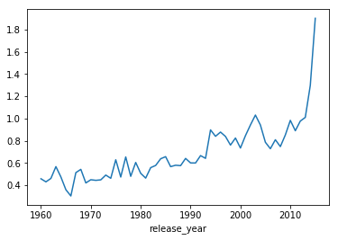

```python
df_profitable_movies.groupby('release_year')['popularity'].mean().plot()
```

Populartity of successful movies has been increasing with years.

### Research Question 9 (Which month had the most number of releases ?)

```python
#Extracting month
df['month_str'] = df['release_date'].dt.strftime('%b')
```

```python
#Calulating number of releases in each month.
monthly_release=df['month_str'].value_counts()
monthly_release.index = pd.CategoricalIndex(monthly_release.index, categories=['Jan', 'Feb', 'Mar', 'Apr','May','Jun', 'Jul', 'Aug','Sep', 'Oct', 'Nov', 'Dec'])

#Sorrting the data as sequence of months
monthly_release = monthly_release.sort_index()
monthly_release
```

```
Jan     892
Feb     681
Mar     813
Apr     791
May     807
Jun     822
Jul     790
Aug     906
Sep    1319
Oct    1138
Nov     798
Dec     974
Name: month_str, dtype: int64
```

**Septemeber and October seems to be preferred months for movie release**

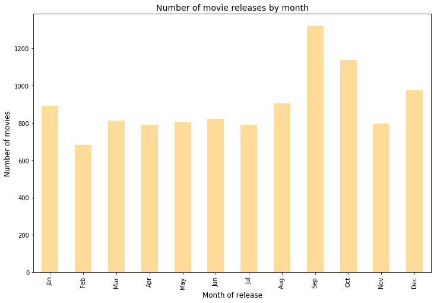

```python
plt.figure(figsize=(12,8))
monthly_release.plot.bar(alpha=0.4,color='orange')

plt.title('Number of movie releases by month',fontsize=14)
plt.xlabel('Month of release',fontsize=12)
plt.ylabel('Number of movies',fontsize=12)
plt.show()
```

### Research Question 10 (Which month has been the most profitable month over the years ?)

```python
#Grouping by monthly profit
monthly_profit=df[df["profit"]>0].groupby("month_str")['profit'].mean()

monthly_profit.index = pd.CategoricalIndex(monthly_profit.index, categories=['Jan', 'Feb', 'Mar', 'Apr','May','Jun', 'Jul', 'Aug','Sep', 'Oct', 'Nov', 'Dec'])

#Sorting as a sequence of month
monthly_profit = monthly_profit.sort_index()
monthly_profit
```

```
month_str
Jan    3.725492e+07
Feb    4.503312e+07
Mar    5.554705e+07
Apr    6.009318e+07
May    9.227757e+07
Jun    9.294947e+07
Jul    8.107658e+07
Aug    4.651884e+07
Sep    4.426076e+07
Oct    4.758257e+07
Nov    8.391499e+07
Dec    7.876967e+07
Name: profit, dtype: float64
```

[figure not shown]

```python
plt.figure(figsize=(12,8))
monthly_profit.plot.bar(alpha=0.4,color='blue')

plt.title('Mean monthly revenue over the years',fontsize=14)
plt.xlabel('Month of release',fontsize=12)
plt.ylabel('Mean revenue',fontsize=12)
plt.show()
```

**June** has been the most successful month over the years. Films released in May/June have earned highest profits.

### Research Question 11 (Which director has made the most number of profitable movies ?)

```python
director_profit=df_profitable_movies.groupby('director')['id'].count().sort_values(ascending=False)
director_profit.head(10)
```

```
director
Clint Eastwood       28
Woody Allen          28
Steven Spielberg     27
Martin Scorsese      22
Ridley Scott         18
Ron Howard           17
Tim Burton           17
Robert Zemeckis      17
Wes Craven           16
Steven Soderbergh    15
Name: id, dtype: int64
```

[figure not shown]

```python
plt.figure(figsize=(12,8))
director_profit.head(10).plot.bar()
plt.title('Mean monthly revenue over the years',fontsize=14)
plt.xlabel('Month of release',fontsize=12)
plt.ylabel('Mean revenue',fontsize=12)
plt.show()
```

**Clint Eastwood,Woody Allen are the directors that have made most number of profitable movies** closely followed by Steven Spielberg

### Research Question 12 (Which production company has been the most successful?)

```python
#Splitting the column'production_company'
prod_split=df_profitable_movies['production_companies'].str.cat(sep='|')
prod_split = pd.Series(prod_split.split('|'))

prod_count = prod_split.value_counts(ascending = False)
prod_count.head(10)
```

```
Universal Pictures                        402
Warner Bros.                              362
Paramount Pictures                        330
Twentieth Century Fox Film Corporation    228
Columbia Pictures                         206
New Line Cinema                           165
Walt Disney Pictures                      160
Metro-Goldwyn-Mayer (MGM)                 147
Touchstone Pictures                       119
Columbia Pictures Corporation             118
dtype: int64
```

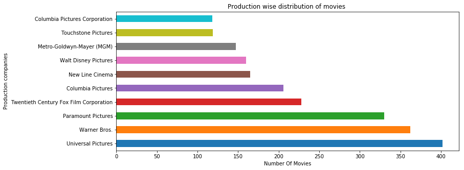

```python
plt.figure(figsize=(12,5))
prod_count.head(10).plot(kind='barh')

plt.title('Production wise distribution of movies ')
plt.xlabel('Number Of Movies')
plt.ylabel('Production companies')
plt.show()
```

**Universal Pictures** releases the most number of profitable movies followed by warner Bros.

## Conclusions

After analysing various parameters of the movie data, I have come up with the following conclusion:

Following parameters ensure for a movie to be succesful:

- Genre: Genre of the movie should be either Drama or Comedy, preferrably Drama.
- Successful cast : Following are the top 3 most succesful cast members: Robert De Niro,Samuel L. Jackson,Tom Hanks.
- Smaller runtime: Runtime of the movie should be within 100 minutes.
- Good production house : Universal Pictures have produced maximum number of hits.
- Great Director: Top 3 most succeful directors are: Clint Eastwood,Woody Allen,Steven Spielberg.
- Appropriate time of release : Months June and May have recorded the maximum profit over the years.

#### Limitations:

1.There were a number of rows where one or more column had null data.Due to this, some of the rows were dropped while others were kept as it is. I can't be completely sure whether it affectd the overall analysis of the data.

2.The above conclusions are not a definite way(100% solution) of a successful movie. These are some of the many parameters that could make a movie successful. However, it does show that with the above parameters in place, there is a high probabality that a movie might be successful.

## Resources

- https://datascience.stackexchange.com/questions/11797/split-a-list-of-values-into-columns-of-a-dataframe
- https://stackoverflow.com/questions/50394099/separate-columns-based-on-genre
- https://stackoverflow.com/questions/26053849/counting-non-zero-values-in-each-column-of-a-dataframe-in-python
- https://stackoverflow.com/questions/44885933/how-to-sort-bars-in-a-bar-plot-in-ascending-order
- https://stackoverflow.com/questions/42234039/getting-the-row-with-max-value-in-pandas
- https://stackoverflow.com/questions/2051744/reverse-y-axis-in-pyplot
- https://letstrythatagain.wordpress.com/2010/01/14/reverse-axis-direction-in-pylab/
- https://pandas.pydata.org/pandas-docs/stable/reference/api/pandas.DataFrame.sort_values.html
- https://stackoverflow.com/questions/44537249/grouping-by-with-where-conditions-in-pandas
- https://stackoverflow.com/questions/40816144/pandas-series-sort-by-month-index

## Submitting your Project

> Before you submit your project, you need to create a .html or .pdf version of this notebook in the workspace here. To do that, run the code cell below. If it worked correctly, you should get a return code of 0, and you should see the generated .html file in the workspace directory (click on the orange Jupyter icon in the upper left).

> Alternatively, you can download this report as .html via the **File** > **Download as** submenu, and then manually upload it into the workspace directory by clicking on the orange Jupyter icon in the upper left, then using the Upload button.

> Once you've done this, you can submit your project by clicking on the "Submit Project" button in the lower right here. This will create and submit a zip file with this .ipynb doc and the .html or .pdf version you created. Congratulations!

```python
from subprocess import call
call(['python', '-m', 'nbconvert', 'Investigate_a_Dataset.ipynb'])
```

```
0
```